# Practical Machine Learning Project

Robert B. Jansen

May 8, 2018

## Background

Using devices such as Jawbone Up, Nike FuelBand, and Fitbit it is now possible to collect a large amount of data about personal activity relatively inexpensively. These type of devices are part of the quantified self movement – a group of enthusiasts who take measurements about themselves regularly to improve their health, to find patterns in their behavior, or because they are tech geeks. One thing that people regularly do is quantify how much of a particular activity they do, but they rarely quantify how well they do it. In this project, your goal will be to use data from accelerometers on the belt, forearm, arm, and dumbell of 6 participants. They were asked to perform barbell lifts correctly and incorrectly in 5 different ways. More information is available from the website here: http://web.archive.org/web/20161224072740/http:/groupware.les.inf.puc-rio.br/har (see the section on the Weight Lifting Exercise Dataset).

The data for this project is courtesy of http://web.archive.org/web/20161224072740/http:/groupware.les.inf.puc-rio.br/har.

## Data modeling

Using the Random Forest method create a predictive model for activity recognition.

```r
control_rf <- trainControl(method="cv", 5)
model_rf <- train(classe ~ ., data=train_data, method="rf", trControl=control_rf, ntree=250)
model_rf
```

```
## Random Forest
##
## 13737 samples
##    52 predictor
##     5 classes: 'A', 'B', 'C', 'D', 'E'
##
## No pre-processing
## Resampling: Cross-Validated (5 fold)
## Summary of sample sizes: 10989, 10989, 10990, 10991, 10989
## Resampling results across tuning parameters:
##
##   mtry  Accuracy   Kappa
##    2    0.9900998  0.9874749
##   27    0.9913372  0.9890417
##   52    0.9828929  0.9783554
##
## Accuracy was used to select the optimal model using the largest value.
## The final value used for the model was mtry = 27.
```

Estimate the performance of the Random Forest method.

```r
predict_rf <- predict(model_rf, test_data)
confusionMatrix(test_data$classe, predict_rf)
```

```
## Confusion Matrix and Statistics
##
##           Reference
## Prediction    A    B    C    D    E
##          A 1670    2    0    0    2
##          B   12 1121    6    0    0
##          C    0    2 1023    1    0
##          D    0    0    9  954    1
##          E    0    1    2    8 1071
##
## Overall Statistics
##
##                Accuracy : 0.9922
##                  95% CI : (0.9896, 0.9943)
##     No Information Rate : 0.2858
##     P-Value [Acc > NIR] : < 2.2e-16
##
##                   Kappa : 0.9901
##  Mcnemar's Test P-Value : NA
##
## Statistics by Class:
##
##                      Class: A Class: B Class: C Class: D Class: E
## Sensitivity            0.9929   0.9956   0.9837   0.9907   0.9972
## Specificity            0.9990   0.9962   0.9994   0.9980   0.9977
## Pos Pred Value         0.9976   0.9842   0.9971   0.9896   0.9898
## Neg Pred Value         0.9972   0.9989   0.9965   0.9982   0.9994
## Prevalence             0.2858   0.1913   0.1767   0.1636   0.1825
## Detection Rate         0.2838   0.1905   0.1738   0.1621   0.1820
## Detection Prevalence   0.2845   0.1935   0.1743   0.1638   0.1839
## Balanced Accuracy      0.9960   0.9959   0.9915   0.9943   0.9975
```

```r
accuracy <- postResample(predict_rf, test_data$classe)
accuracy
```

```
##  Accuracy     Kappa
## 0.9921835 0.9901120
```

```r
out_of_sample <- 1 - as.numeric(confusionMatrix(test_data$classe, predict_rf)$overall[1])
out_of_sample
```

```
## [1] 0.007816483
```

```r
result <- predict(model_rf, test_clean[, -length(names(test_clean))])
result
```

```
##  [1] B A B A A E D B A A B C B A E E A B B B
## Levels: A B C D E
```

## Appendix: Data visualizations

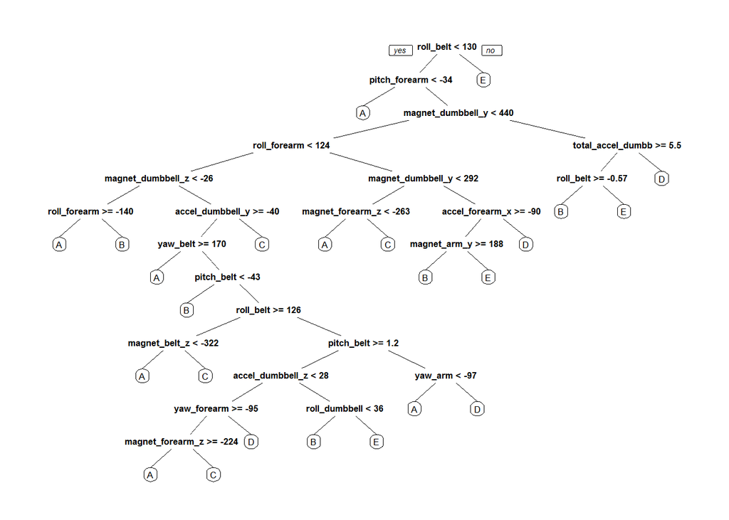

```r
#Decision Tree Visulization
treeModel <- rpart(classe ~ ., data=train_data, method="class")
prp(treeModel) # fast plot
```

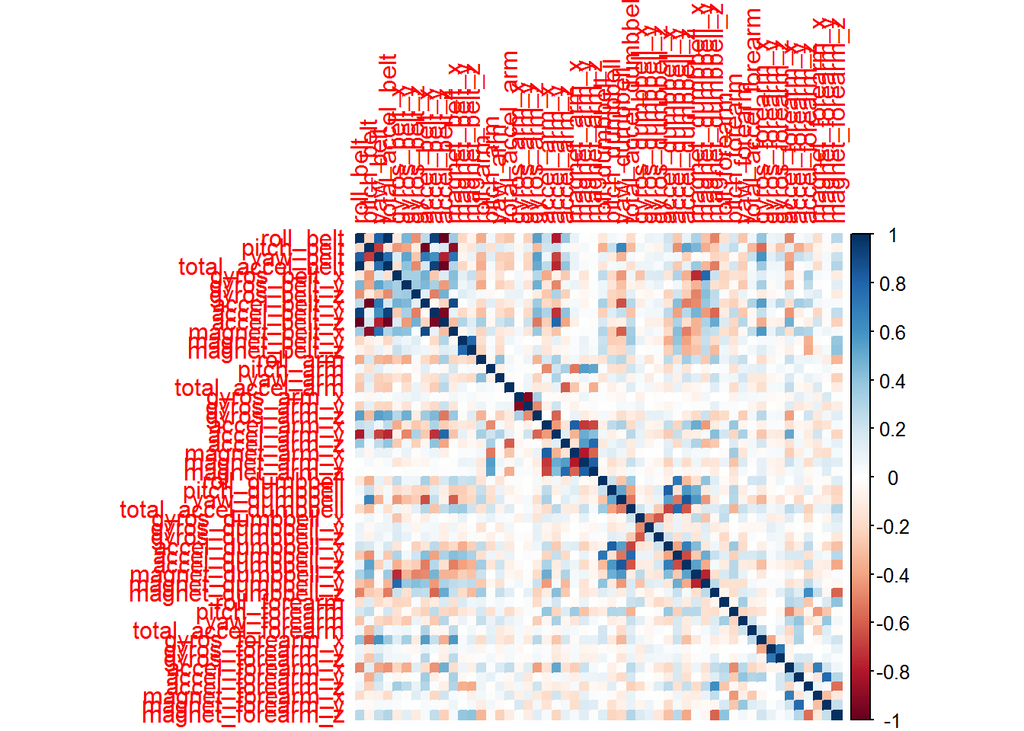

```r
# Correlation Plot
corrPlot <- cor(train_data[, -length(names(train_data))])
corrplot(corrPlot, method="color")
```